# AActivityQuality

pwg137

Saturday, March 21, 2015

Prediction of Activity Quality using Machine Learning

pwg137 (My email handle)

Introduction

For the Practical Machine Learning class, students were asked to construct a machine learning algorithm to predict activity quality from the results in a training data set. They are asked to submit the algorithm, and discuss out of sample error estimates from cross-validation. This paper contains the results, the machine learning algorithm, and some discussion.

Results

The machine learning algorithm got 10 of 20 right when it was submitted against the test cases. This is better than chance, but not great. Probabilities of correct classification ranged from 30% to 99%. Unsurprisingly, the higher probability items tended to be correctly classified.

Algorithm

The machine learning algorithm is shown below. I commented out the file write section for use with knitr. The approach taken was to look for physically significant variables, ensure they would be present in the test set, subset the data so as to consider only significant variables, and look for a model which could identify all of the activity classes. Most models were unable to identify one or more classes. The brute force approach produced a classification based on event number, and eliminating the first 7 columns produced a model that crashed on the test set. I opted to use the rpart method, which has a default of 10-fold cross-validation.

Here is the algorithm.

```r
  input<-read.csv("pml-training.csv")
    qvec<-read.csv("pml-testing.csv")
    svec<-c(37:45,60:68,121:124,151:160)
    newinput<-input[,svec]
    qvecsub<-qvec[,svec]
    library(caret)
    library(rpart)
    rpart.control(minsplit=10)
```

```
## $minsplit
## [1] 10
##
## $minbucket
## [1] 3
##
## $cp
## [1] 0.01
##
## $maxcompete
## [1] 4
##
## $maxsurrogate
## [1] 5
##
## $usesurrogate
## [1] 2
##
## $surrogatestyle
## [1] 0
##
## $maxdepth
## [1] 30
##
## $xval
## [1] 10
```

```r
    model<-train(classe~.,method="rpart",data=newinput)
    test<-predict(model$finalModel,newdata=qvecsub,type="class")
##  pml_write_files = function(x){
##          n = length(x)
##          for(i in 1:n){
##          filename = paste0("problem_id_",i,".txt")
##          write.table(x[i],file=filename,quote=FALSE,row.names=FALSE,col.names=FALSE)
##          }
##  }
##  pml_write_files(test)
```

Discussion

Here is a plot of the decision tree produced by the final model. It classifies all types of activities. It is dominated by activity A, which is true for the data set.

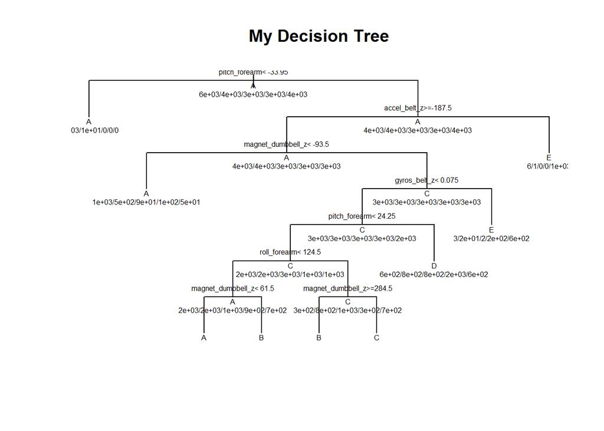

```r
plot(model$finalModel,uniform=TRUE,main="My Decision Tree")
  text(model$finalModel,use.n=TRUE,all=TRUE,cex=0.5)
```

The final model is shown here.

```r
model$finalModel
```

```
## n= 19622
##
## node), split, n, loss, yval, (yprob)
##       * denotes terminal node
##
##   1) root 19622 14040 A (0.28 0.19 0.17 0.16 0.18)
##     2) pitch_forearm< -33.95 1578    10 A (0.99 0.0063 0 0 0) *
##     3) pitch_forearm>=-33.95 18044 14030 A (0.22 0.21 0.19 0.18 0.2)
##       6) accel_belt_z>=-187.5 17009 13000 A (0.24 0.22 0.2 0.19 0.15)
##        12) magnet_dumbbell_z< -93.5 1893   781 A (0.59 0.28 0.047 0.058 0.027) *
##        13) magnet_dumbbell_z>=-93.5 15116 11780 C (0.19 0.22 0.22 0.21 0.17)
##          26) gyros_belt_z< 0.075 14282 10950 C (0.2 0.23 0.23 0.2 0.14)
##            52) pitch_forearm< 24.25 9860  7303 C (0.23 0.25 0.26 0.12 0.14)
##             104) roll_forearm< 124.5 6450  4455 A (0.31 0.25 0.2 0.14 0.1)
##               208) magnet_dumbbell_z< 61.5 3904  2179 A (0.44 0.2 0.15 0.13 0.072) *
##               209) magnet_dumbbell_z>=61.5 2546  1703 B (0.11 0.33 0.27 0.14 0.15) *
##             105) roll_forearm>=124.5 3410  2118 C (0.088 0.24 0.38 0.077 0.22)
##               210) magnet_dumbbell_z>=284.5 971   656 B (0.29 0.32 0.023 0.11 0.25) *
##               211) magnet_dumbbell_z< 284.5 2439  1169 C (0.0078 0.21 0.52 0.064 0.2) *
##            53) pitch_forearm>=24.25 4422  2715 D (0.13 0.18 0.18 0.39 0.13) *
##          27) gyros_belt_z>=0.075 834   270 E (0.0036 0.018 0.0024 0.3 0.68) *
##       7) accel_belt_z< -187.5 1035     7 E (0.0058 0.00097 0 0 0.99) *
```

Cross-validation and Out-of-Sample Error

The rpart method performs 10-fold cross-validation, as shown above in the execution of the machine learning algorithm, The object cptable in the final model is supposed to contain information regarding complexity parameters and out of sample error. Unfortunately, it doesn’t. The cptable object is summarized below.

```r
summary(model$finalModel$cptable)
```

```
##        CP             nsplit      rel error
##  Min.   :0.0206   Min.   :0.0   Min.   :0.676
##  1st Qu.:0.0207   1st Qu.:3.5   1st Qu.:0.686
##  Median :0.0209   Median :7.0   Median :0.697
##  Mean   :0.0260   Mean   :5.0   Mean   :0.791
##  3rd Qu.:0.0286   3rd Qu.:7.5   3rd Qu.:0.848
##  Max.   :0.0364   Max.   :8.0   Max.   :1.000
```